# Notebook 17 – Solutions

## Parsing Wikipedia

In previous notes we have used the MediaWiki API to grab information about the number of page views there have been in the past 60 days for each page associated with a row in our `foods` dataset. The API also allows us to grab data about the actual current content of any page on Wikipedia. Here is the query string for accessing the page for “apple”:

```r
url_str <- modify_url("https://en.wikipedia.org/w/api.php",
                       query = list(action = "parse", format = "json", page = "apple"))

res <- http_cache_get(url_str, cache_dir = "cache")
obj <- content(res, type = "application/json")
```

Calling the query string yields a JSON object that contains some metadata about the page contents. It also contains a text representation of the page parsed into HTML. In summary, the JSON file contains an element that is in HTML (!). Here is the a sample of the HTML file:

```r
html_txt <- obj$parse$text[["*"]]
stri_wrap(stri_sub(html_txt, 1, 1000), 70)
```

```
##  [1] "<div class=\"mw-parser-output\"><div class=\"shortdescription"
##  [2] "nomobile noexcerpt noprint searchaux\" style=\"display:none\">Edible"
##  [3] "fruit of domesticated deciduous tree</div> <style data-"
##  [4] "mw-deduplicate=\"TemplateStyles:r1033289096\">.mw-parser-"
##  [5] "output .hatnote{font-style:italic}.mw-parser-output"
##  [6] "div.hatnote{padding-left:1.6em;margin-bottom:0.5em}.mw-"
##  [7] "parser-output .hatnote i{font-style:normal}.mw-parser-"
##  [8] "output .hatnote+link+.hatnote{margin-top:-0.5em}</style><div"
##  [9] "role=\"note\" class=\"hatnote navigation-not-searchable\">This article"
## [10] "is about the fruit and tree. For the American technology company,"
## [11] "see <a href=\"/wiki/Apple_Inc.\" title=\"Apple Inc.\">Apple Inc.</a> For"
## [12] "other uses, see <a href=\"/wiki/Apple_(disambiguation)\" class=\"mw-"
## [13] "disambig\" title=\"Apple (disambiguation)\">Apple (disambiguation)</"
## [14] "a>, <a href=\"/wiki/Apple_blossom_(disambiguation)\" class=\"mw-redirect"
## [15] "mw-disambig\" title=\"Apple blossom (disambiguation)\">Apple blossom"
## [16] "(disambiguation)</a>, and <a href=\"/wiki/Apple_tree_(disambiguation)\""
## [17] "class"
```

Now, we can use the `read_html` function to convert the text into an `html_document`.

```r
obj_html <- read_html(html_txt)
obj_html
```

```
## {html_document}
## <html>
## [1] <body><div class="mw-parser-output">\n<div class="shortdescription nomobile no ...
```

The larger JSON object contains a set of all links that are found on the page, but it does not tell us where they occur in the page. This can be a problem because it includes lots of extra links found at the top and bottom on the page. To get a more accurate sense of the links within the body of the text, we need to grab them from the parsed HTML.

In the code below, extract all of the links (the “a” tag) that are somewhere inside the paragraph tags (“p”) of the Wikipedia text.

```r
xml_find_all(obj_html, ".//p//a")
```

```
## {xml_nodeset (414)}
##  [1] <a href="/wiki/Fruit" title="Fruit">fruit</a>
##  [2] <a href="/wiki/Fruit_tree" title="Fruit tree">trees</a>
##  [3] <a href="/wiki/Agriculture" title="Agriculture">cultivated</a>
##  [4] <a href="/wiki/Genus" title="Genus">genus</a>
##  [5] <a href="/wiki/Malus" title="Malus">Malus</a>
##  [6] <a href="/wiki/Tree" title="Tree">tree</a>
##  [7] <a href="/wiki/Central_Asia" title="Central Asia">Central Asia</a>
##  [8] <a href="/wiki/Malus_sieversii" title="Malus sieversii">Malus sieversii</a>
##  [9] <a href="/wiki/Asia" title="Asia">Asia</a>
## [10] <a href="/wiki/Europe" title="Europe">Europe</a>
## [11] <a href="/wiki/European_colonization_of_the_Americas" title="European coloniz ...
## [12] <a href="/wiki/Religion" title="Religion">religious</a>
## [13] <a href="/wiki/Mythology" class="mw-redirect" title="Mythology">mythological</a>
## [14] <a href="/wiki/Norse_mythology" title="Norse mythology">Norse</a>
## [15] <a href="/wiki/Greek_mythology" title="Greek mythology">Greek</a>
## [16] <a href="/wiki/Christianity_in_Europe" title="Christianity in Europe">Europea ...
## [17] <a href="/wiki/Cultivar" title="Cultivar">cultivars</a>
## [18] <a href="/wiki/Grafting" title="Grafting">grafting</a>
## [19] <a href="/wiki/Rootstock" title="Rootstock">rootstocks</a>
## [20] <a href="/wiki/List_of_apple_cultivars" title="List of apple cultivars">culti ...
## ...
```

Now, create a data table that has three columns: `item` (which is always equal to “Apple”), `link` giving the href url within each of the links found above, and `text` giving the text inside the links above. Name the dataset `wiki_links`

```r
wiki_links <- tibble(
  item = "Apple",
  link = xml_attr(xml_find_all(obj_html, ".//p//a"), "href"),
  text = xml_text(xml_find_all(obj_html, ".//p//a"))
)

wiki_links
```

```
## # A tibble: 414 × 3
##    item  link                  text
##    <chr> <chr>                 <chr>
##  1 Apple /wiki/Fruit           fruit
##  2 Apple /wiki/Fruit_tree      trees
##  3 Apple /wiki/Agriculture     cultivated
##  4 Apple /wiki/Genus           genus
##  5 Apple /wiki/Malus           Malus
##  6 Apple /wiki/Tree            tree
##  7 Apple /wiki/Central_Asia    Central Asia
##  8 Apple /wiki/Malus_sieversii Malus sieversii
##  9 Apple /wiki/Asia            Asia
## 10 Apple /wiki/Europe          Europe
## # … with 404 more rows
```

Some of the links you found above may be to external pages or to footnotes. Filter the `wiki_links` to include only those that start with “/wiki/” and then remove the leading “/wiki/” from the remaining links. Resave the data as `wiki_links`.

```r
wiki_links <- wiki_links %>%
  filter(stri_sub(link, 1L, 6L) == "/wiki/") %>%
  mutate(link = stri_sub(link, 7L, -1L))

wiki_links
```

```
## # A tibble: 290 × 3
##    item  link            text
##    <chr> <chr>           <chr>
##  1 Apple Fruit           fruit
##  2 Apple Fruit_tree      trees
##  3 Apple Agriculture     cultivated
##  4 Apple Genus           genus
##  5 Apple Malus           Malus
##  6 Apple Tree            tree
##  7 Apple Central_Asia    Central Asia
##  8 Apple Malus_sieversii Malus sieversii
##  9 Apple Asia            Asia
## 10 Apple Europe          Europe
## # … with 280 more rows
```

Now, without saving the output, look at the items in `wiki_links` where a lowercase version of the link does not each a lowercase version of the text. What differences do you see?

```r
wiki_links %>%
  filter(stri_trans_tolower(link) != stri_trans_tolower(text))
```

```
## # A tibble: 186 × 3
##    item  link                                  text
##    <chr> <chr>                                 <chr>
##  1 Apple Fruit_tree                            trees
##  2 Apple Agriculture                           cultivated
##  3 Apple Central_Asia                          Central Asia
##  4 Apple Malus_sieversii                       Malus sieversii
##  5 Apple European_colonization_of_the_Americas European colonists
##  6 Apple Religion                              religious
##  7 Apple Mythology                             mythological
##  8 Apple Norse_mythology                       Norse
##  9 Apple Greek_mythology                       Greek
## 10 Apple Christianity_in_Europe                European Christian
## # … with 176 more rows
```

Now, create a summarized version of `wiki_links` that has one row for each unique link, with a count column. Arrange the links from the highest to the lowest number. You don’t need the text column here.

```r
wiki_links %>%
  group_by(item, link) %>%
  summarize(n = n()) %>%
  ungroup() %>%
  arrange(desc(n))
```

```
## # A tibble: 256 × 3
##    item  link                n
##    <chr> <chr>           <int>
##  1 Apple Rootstock           4
##  2 Apple Cooking_apple       3
##  3 Apple Fruit               3
##  4 Apple Organic_farming     3
##  5 Apple Apple_butter        2
##  6 Apple Apple_cider         2
##  7 Apple Apple_juice         2
##  8 Apple Apple_pie           2
##  9 Apple Apple_sauce         2
## 10 Apple Asia                2
## # … with 246 more rows
```

## Covid Dashboard

As a second task, let’s try to use our XML skills to grab data from the UR COVID dashboard. I will give you the code here to grab the page; you may find it useful to visit the page in a browser as well.

```r
url_str <- modify_url("https://www.richmond.edu/coronavirus/dashboard/index.html",)
res <- http_cache_get(url_str, cache_dir = "cache")
obj <- content(res, type = "text/html", encoding = "UTF-8")
obj
```

```
## {html_document}
## <html xmlns="http://www.w3.org/1999/xhtml" class="no-js" dir="ltr" lang="en">
## [1] <head>\n<meta http-equiv="Content-Type" content="text/html; charset=UTF-8">\n< ...
## [2] <body class="www-secondary">\n    \n    \n   \n\n    <header><!-- SKIP TO LINK ...
```

The number of cases from the past seven weeks is given in an html table, which we can find with the `tbody` tag. Extract this table (there is only one) in the code below:

```r
xml_find_all(obj, ".//tbody")
```

```
## {xml_nodeset (1)}
## [1] <tbody>\n<tr>\n<th scope="row">8/29-9/4/2021</th>\r\n\t\t\t\t\t<td class="bar  ...
```

Inside the table are table rows (`tr`) and inside each table row of a table header (`th`). Grab the text of these seven table headers below:

```r
xml_text(xml_find_all(obj, ".//tbody/tr/th"))
```

```
## [1] "8/29-9/4/2021"  "9/5-11/2021"    "9/12-18/2021"   "9/19-25/2021"
## [5] "9/26-10/2/2021" "10/3-9/2021"    "10/10-16/2021"
```

Each table row also has a table data element (`td`); usually there are more than one of these in each row, but here there’s just one. In this example, there is also a paragraph tag (`p`) inside each table data element. Grab the text of these paragraphs below:

```r
xml_text(xml_find_all(obj, ".//tbody/tr/td/p"))
```

```
## [1] "9"  "3"  "5"  "13" "3"  "2"  "3"
```

Putting together your last two answers, create an tibble that has the date of each record and count of positive COVID-19 cases. Save the data as an object named `cases`.

```r
cases <- tibble(
  date = xml_text(xml_find_all(obj, ".//tbody/tr/th")),
  count = as.numeric(xml_text(xml_find_all(obj, ".//tbody/tr/td/p")))
)
cases
```

```
## # A tibble: 7 × 2
##   date           count
##   <chr>          <dbl>
## 1 8/29-9/4/2021      9
## 2 9/5-11/2021        3
## 3 9/12-18/2021       5
## 4 9/19-25/2021      13
## 5 9/26-10/2/2021     3
## 6 10/3-9/2021        2
## 7 10/10-16/2021      3
```

Finally, recreate the bar plot from the website in R using your data from above.

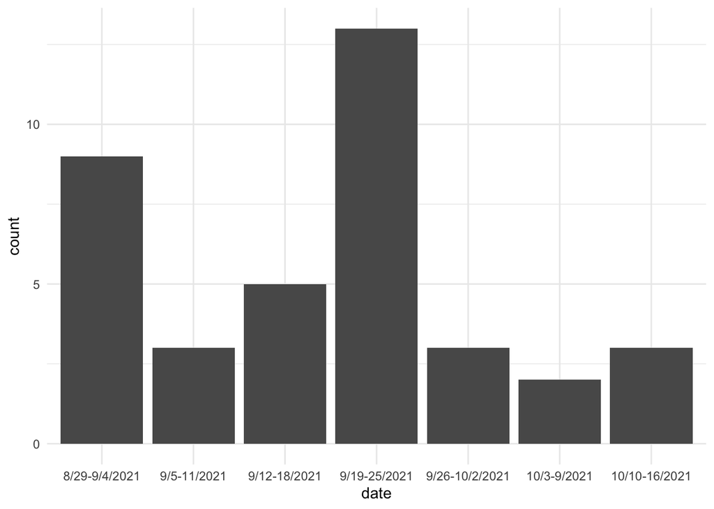

```r
cases %>%
  mutate(date = fct_inorder(date)) %>%
  ggplot(aes(date, count)) +
    geom_col()
```